# Chapter 6 homework

Author

Zhe Chen

Published

February 20, 2026

## Setup

```r
library(tidyverse)
library(tinyplot)
library(here)
```

## Data

This homework uses a built-in dataset from base R (`state.x77`). Run the code below to create the working tibble `states`.

```r
state.x77_with_names <- as_tibble(state.x77,
                                  rownames = "state")

states <- bind_cols(state.x77_with_names,
                    region = state.division) |>
  janitor::clean_names() |>
  mutate(
    south = as.integer(
      str_detect(as.character(region), "South")
    )
  )
```

Throughout, use:

- outcome: `life_exp`
- predictor: `murder`

# Question 1: Descriptive statistics

## 1a. Descriptive statistics (psych)

Use `psych::describe()` (or something else if you want) to get descriptive statistics for `life_exp` and `murder`.

```r
states |>
  select(life_exp, murder) |>
  psych::describe()
```

```
         vars  n  mean   sd median trimmed  mad   min  max range  skew kurtosis
life_exp    1 50 70.88 1.34  70.67   70.92 1.54 67.96 73.6  5.64 -0.15    -0.67
murder      2 50  7.38 3.69   6.85    7.30 5.19  1.40 15.1 13.70  0.13    -1.21
           se
life_exp 0.19
murder   0.52
```

## 1b. Descriptive statistics (tidyverse)

Compute (at minimum) the mean and standard deviation of `life_exp` and `murder` using `summarize()`.

```r
states |>
  select(life_exp, murder) |>
  summarize(
    mean_life_exp = mean(life_exp),
    sd_life_exp = sd(life_exp),
    mean_murder = mean(murder),
    sd_murder = sd(murder)
  )
```

```
# A tibble: 1 × 4
  mean_life_exp sd_life_exp mean_murder sd_murder
          <dbl>       <dbl>       <dbl>     <dbl>
1          70.9        1.34        7.38      3.69
```

# Question 2a: Regression and model comparison

You will evaluate whether `murder` predicts `life_exp`.

## 2a(i). Write the model comparison and null hypothesis

Write Model C and Model A in words and equations, and state the null hypothesis.

A typical setup for testing whether a slope is needed is:

- Model C (constrained): slope fixed at 0
- Model A (augmented): slope estimated from the data

Use the notation below (fill in the missing pieces in your write-up):

Model C:

$$Y_i = \;\;\;\;\;\;\;\; + \varepsilon_i$$

Model A:

$$Y_i = \;\;\;\;\;\;\;\; + \;\;\;\;\;\;\;\; X_i + \varepsilon_i$$

Null hypothesis (in symbols and words):

$$H_0: \;\;\;\;\;\;\;\;$$

Model C: Murder rate is not associated with life expectancy at the state level.

$$Life\_exp_i = \beta_0 + \varepsilon_i$$

Model A: Murder rate is associated with life expectancy at the state level.

$$Life\_exp_i = \beta_0 + \beta_1Murder_i + \varepsilon_i$$

Null hypothesis: The slope of murder rate is 0.

$$H_0: \beta_1 = 0$$

## 2a(ii). Fit both models

```r
mc <- lm(life_exp ~ 1, data = states)
ma <- lm(life_exp ~ 1 + murder, data = states)
```

## 2a(iii). Compute SSE(C), SSE(A), PRE, and F

Compute:

- $\mathrm{SSE}_C$ and $\mathrm{SSE}_A$ from the fitted models
- $\mathrm{PRE} = (\mathrm{SSE}_C - \mathrm{SSE}_A)/\mathrm{SSE}_C$
- the model-comparison $F$ statistic

Use `deviance()` for SSE (RSS) and `df.residual()` as needed.

$$F = \frac{(\mathrm{SSE}_C - \mathrm{SSE}_A)/(P_A - P_C)}{\mathrm{SSE}_A/(n - P_A)}.$$

```r
# SSE_C
sse_c <- deviance(mc)
sse_c
```

```
[1] 88.299
```

```r
# SSE_A
sse_a <- deviance(ma)
sse_a
```

```
[1] 34.46133
```

```r
# PRE
pre <- (sse_c - sse_a) / sse_c
pre
```

```
[1] 0.6097201
```

```r
# F
pc <- nrow(states) - df.residual(mc)
pc
```

```
[1] 1
```

```r
pa <- nrow(states) - df.residual(ma)
pa
```

```
[1] 2
```

```r
n <- nrow(states)
n
```

```
[1] 50
```

```r
f <- ((sse_c - sse_a) / (pa - pc)) / (sse_a / (n - pa))
f
```

```
[1] 74.98865
```

## 2a(iv). Write the prediction equation and interpret coefficients

```r
# model summary
summary(ma)
```

```
Call:
lm(formula = life_exp ~ 1 + murder, data = states)

Residuals:
     Min       1Q   Median       3Q      Max
-1.81690 -0.48139  0.09591  0.39769  2.38691

Coefficients:
            Estimate Std. Error t value Pr(>|t|)
(Intercept) 72.97356    0.26997  270.30  < 2e-16 ***
murder      -0.28395    0.03279   -8.66 2.26e-11 ***
---
Signif. codes:  0 '***' 0.001 '**' 0.01 '*' 0.05 '.' 0.1 ' ' 1

Residual standard error: 0.8473 on 48 degrees of freedom
Multiple R-squared:  0.6097,    Adjusted R-squared:  0.6016
F-statistic: 74.99 on 1 and 48 DF,  p-value: 2.26e-11
```

```r
t <- -sqrt(f)
t
```

```
[1] -8.659599
```

```r
pf <- pf(f, 1, 48, lower.tail = FALSE)
pf
```

```
[1] 2.26007e-11
```

```r
pt <- 2 * pt(t, 48)
pt
```

```
[1] 2.26007e-11
```

Write the prediction equation implied by Model A:

$$\widehat{Life\_exp} = 72.97 - 0.28(Murder)$$

Interpret:

- the intercept:
  - When the state’s murder rate is 0%, its average life expectancy is 72.97 years.
- the slope:
  - For each percentage increase in the state’s murder rate, the average life expectancy decreases by 0.28 years.

## 2a(v). Conclusion

State:

- statistical conclusion (report $F$ or $t$, PRE, and $p$):
  - By moving from Model C to Model A, the PRE is 0.61, with the $F$ is 74.99 ($t$ = -8.66), $p$ = 2.26e-11. In other words, given the null hypothesis is true, the observed $F$ is very surprising. Therefore, we should reject the null hypothesis.
- substantive conclusion (in plain language)
  - Murder rate is negatively associated with average life expectancy at the state level. For each percentage increase in the state’s murder rate, its average life expectancy decreases by 0.28 years.

# Question 2b: Center the predictor

Create a centered version of murder:

## 2b(i). Create `murder_c` and refit the model

```r
states <- states |>
  mutate(murder_c = murder - mean(murder))

mc_c <- lm(life_exp ~ 1, data = states)
ma_c <- lm(life_exp ~ 1 + murder_c, data = states)
```

## 2b(ii). Report SSE(A), SSE(C), PRE, and F again

Compute the same fit statistics (SSE, PRE, F). Compare them to the results from Question 2a.

```r
# SSE_C
sse_c_c <- deviance(mc_c)
sse_c_c
```

```
[1] 88.299
```

```r
# SSE_A
sse_a_c <- deviance(ma_c)
sse_a_c
```

```
[1] 34.46133
```

```r
# PRE
pre_c <- (sse_c_c - sse_a_c) / sse_c_c
pre_c
```

```
[1] 0.6097201
```

```r
# F
pc_c <- nrow(states) - df.residual(mc_c)
pc_c
```

```
[1] 1
```

```r
pa_c <- nrow(states) - df.residual(ma_c)
pa_c
```

```
[1] 2
```

```r
n_c <- nrow(states)
n_c
```

```
[1] 50
```

```r
f_c <- ((sse_c_c - sse_a_c) / (pa_c - pc_c)) / (sse_a_c / (n_c - pa_c))
f_c
```

```
[1] 74.98865
```

```r
# compare with 2a
all.equal(sse_c, sse_c_c)
```

```
[1] TRUE
```

```r
all.equal(sse_a, sse_a_c)
```

```
[1] TRUE
```

```r
all.equal(pre, pre_c)
```

```
[1] TRUE
```

```r
all.equal(f, f_c)
```

```
[1] TRUE
```

The SSE_C, SSE_A, PRE, F are the same as those in 2a.

## 2b(iii). Interpret coefficients after centering

```r
# model summary
summary(ma_c)
```

```
Call:
lm(formula = life_exp ~ 1 + murder_c, data = states)

Residuals:
     Min       1Q   Median       3Q      Max
-1.81690 -0.48139  0.09591  0.39769  2.38691

Coefficients:
            Estimate Std. Error t value Pr(>|t|)
(Intercept) 70.87860    0.11983  591.50  < 2e-16 ***
murder_c    -0.28395    0.03279   -8.66 2.26e-11 ***
---
Signif. codes:  0 '***' 0.001 '**' 0.01 '*' 0.05 '.' 0.1 ' ' 1

Residual standard error: 0.8473 on 48 degrees of freedom
Multiple R-squared:  0.6097,    Adjusted R-squared:  0.6016
F-statistic: 74.99 on 1 and 48 DF,  p-value: 2.26e-11
```

```r
t_c <- -sqrt(f_c)
t_c
```

```
[1] -8.659599
```

```r
pf_c <- pf(f_c, 1, 48, lower.tail = FALSE)
pf_c
```

```
[1] 2.26007e-11
```

```r
pt_c <- 2 * pt(t_c, 48)
pt_c
```

```
[1] 2.26007e-11
```

Write the prediction equation for the centered model and interpret the intercept and slope.

In particular: what does the intercept represent *now*?

$$\widehat{Life\_exp} = 70.88 - 0.28(Murder\_c)$$

Interpret:

- the intercept:
  - When the state’s murder rate is the mean value (7.38), its average life expectancy is 70.88 years.
- the slope:
  - For each percentage increase in the state’s murder rate, the average life expectancy decreases by 0.28 years.

## 2b(iv). Plot and compare

Make two scatterplots with regression lines:

1. `life_exp` vs. `murder`
2. `life_exp` vs. `murder_c`

How are these plots different?

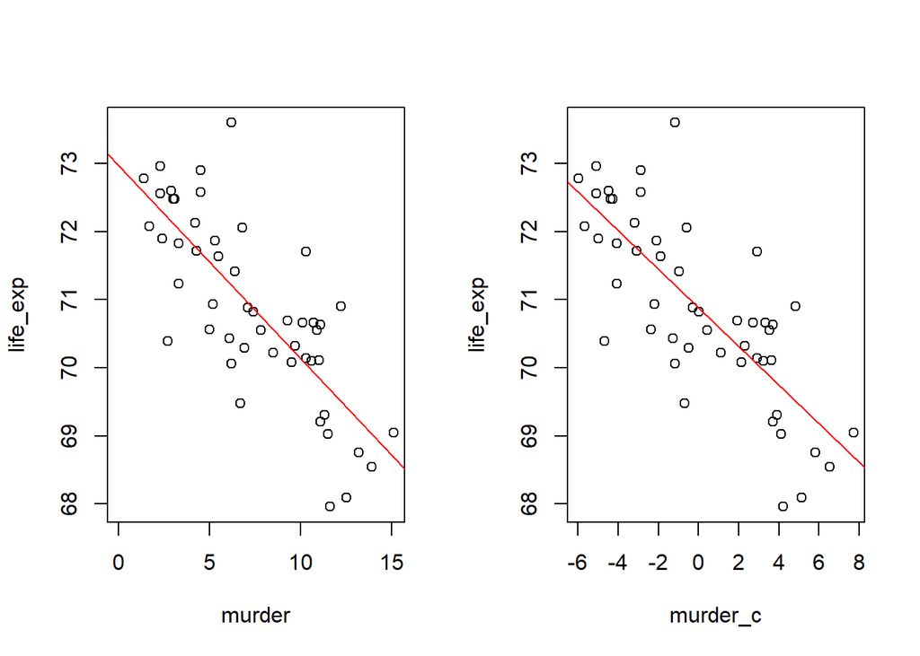

```r
par(mfrow = c(1, 2))

# life_exp vs. murder
tinyplot(life_exp ~ murder, data = states,
          xlim = c(0, max(states$murder)))
abline(lm(life_exp ~ murder, data = states), col = "red")

# life_exp vs. murder_c
tinyplot(life_exp ~ murder_c, data = states)
abline(lm(life_exp ~ murder_c, data = states), col = "red")
```

These two plot have the same slopes, as the the $b_1$ in 2a and 2b is the same. However, the intercepts are different. In `life_exp` vs. `murder`, the intercept indicates the prediction of average life expectancy when the murder rate is 0; while in `life_exp` vs. `murder_c`, the intercept indicates the prediction of average life expectancy when the murder rate is the mean value.

# Question 2c: Change the units of the predictor

Create a transformed predictor by standardizing `murder`.

## 2c(i). Create `murder_std` and refit the model

```r
states <- states |>
  mutate(murder_std = (murder - mean(murder)) / sd(murder))

mc_std <- lm(life_exp ~ 1, data = states)
ma_std <- lm(life_exp ~ 1 + murder_std, data = states)
```

## 2c(ii). Report SSE(A), SSE(C), PRE, and F again

Compute SSE, PRE, and F again and compare them to 2a and 2b.

```r
# SSE_C
sse_c_std <- deviance(mc_std)
sse_c_std
```

```
[1] 88.299
```

```r
# SSE_A
sse_a_std <- deviance(ma_std)
sse_a_std
```

```
[1] 34.46133
```

```r
# PRE
pre_std <- (sse_c_std - sse_a_std) / sse_c_std
pre_std
```

```
[1] 0.6097201
```

```r
# F
pc_std <- nrow(states) - df.residual(mc_std)
pc_std
```

```
[1] 1
```

```r
pa_std <- nrow(states) - df.residual(ma_std)
pa_std
```

```
[1] 2
```

```r
n_std <- nrow(states)
n_std
```

```
[1] 50
```

```r
f_std <- ((sse_c_std - sse_a_std) / (pa_std - pc_std)) / (sse_a_std / (n_std - pa_std))
f_std
```

```
[1] 74.98865
```

```r
# compare with 2a, 2b
all.equal(sse_c, sse_c_c, sse_c_std)
```

```
[1] TRUE
```

```r
all.equal(sse_a, sse_a_c, sse_a_std)
```

```
[1] TRUE
```

```r
all.equal(pre, pre_c, pre_std)
```

```
[1] TRUE
```

```r
all.equal(f, f_c, f_std)
```

```
[1] TRUE
```

The SSE_C, SSE_A, PRE, F are the same as those in 2a and 2b

## 2c(iii). Interpret coefficients after rescaling

Write the prediction equation and interpret the slope carefully in the new units.

```r
# model summary
summary(ma_std)
```

```
Call:
lm(formula = life_exp ~ 1 + murder_std, data = states)

Residuals:
     Min       1Q   Median       3Q      Max
-1.81690 -0.48139  0.09591  0.39769  2.38691

Coefficients:
            Estimate Std. Error t value Pr(>|t|)
(Intercept)  70.8786     0.1198  591.50  < 2e-16 ***
murder_std   -1.0482     0.1210   -8.66 2.26e-11 ***
---
Signif. codes:  0 '***' 0.001 '**' 0.01 '*' 0.05 '.' 0.1 ' ' 1

Residual standard error: 0.8473 on 48 degrees of freedom
Multiple R-squared:  0.6097,    Adjusted R-squared:  0.6016
F-statistic: 74.99 on 1 and 48 DF,  p-value: 2.26e-11
```

```r
t_std <- -sqrt(f_std)
t_std
```

```
[1] -8.659599
```

```r
pf_std <- pf(f_std, 1, 48, lower.tail = FALSE)
pf_std
```

```
[1] 2.26007e-11
```

```r
pt_std <- 2 * pt(t_std, 48)
pt_std
```

```
[1] 2.26007e-11
```

$$\widehat{Life\_exp} = 70.88 - 1.05(Murder\_std)$$

Interpret:

# Question 3: Predicted values and what transformations do (and do not) change

You now have three versions of the same basic relationship:

1. using `murder`
2. using `murder_c`
3. using `murder_std`

## 3a. Predicted life expectancy at a specific murder rate

Using each of your three fitted Model A versions, compute the predicted life expectancy for a state with `murder` = 8.

Show your work. (Be explicit about how you convert 8 into the appropriate value for `murder_c` and `murder_std`.)

```r
# using murder
summary(ma)
```

```
Call:
lm(formula = life_exp ~ 1 + murder, data = states)

Residuals:
     Min       1Q   Median       3Q      Max
-1.81690 -0.48139  0.09591  0.39769  2.38691

Coefficients:
            Estimate Std. Error t value Pr(>|t|)
(Intercept) 72.97356    0.26997  270.30  < 2e-16 ***
murder      -0.28395    0.03279   -8.66 2.26e-11 ***
---
Signif. codes:  0 '***' 0.001 '**' 0.01 '*' 0.05 '.' 0.1 ' ' 1

Residual standard error: 0.8473 on 48 degrees of freedom
Multiple R-squared:  0.6097,    Adjusted R-squared:  0.6016
F-statistic: 74.99 on 1 and 48 DF,  p-value: 2.26e-11
```

```r
life_exp <- 72.97356 - 0.28395 * 8
life_exp
```

```
[1] 70.70196
```

```r
# using murder_c
summary(ma_c)
```

```
Call:
lm(formula = life_exp ~ 1 + murder_c, data = states)

Residuals:
     Min       1Q   Median       3Q      Max
-1.81690 -0.48139  0.09591  0.39769  2.38691

Coefficients:
            Estimate Std. Error t value Pr(>|t|)
(Intercept) 70.87860    0.11983  591.50  < 2e-16 ***
murder_c    -0.28395    0.03279   -8.66 2.26e-11 ***
---
Signif. codes:  0 '***' 0.001 '**' 0.01 '*' 0.05 '.' 0.1 ' ' 1

Residual standard error: 0.8473 on 48 degrees of freedom
Multiple R-squared:  0.6097,    Adjusted R-squared:  0.6016
F-statistic: 74.99 on 1 and 48 DF,  p-value: 2.26e-11
```

```r
life_exp_c <- 70.87860 - 0.28395 * (8 - mean(states$murder))
life_exp_c
```

```
[1] 70.70198
```

```r
# using murder_std
summary(ma_std)
```

```
Call:
lm(formula = life_exp ~ 1 + murder_std, data = states)

Residuals:
     Min       1Q   Median       3Q      Max
-1.81690 -0.48139  0.09591  0.39769  2.38691

Coefficients:
            Estimate Std. Error t value Pr(>|t|)
(Intercept)  70.8786     0.1198  591.50  < 2e-16 ***
murder_std   -1.0482     0.1210   -8.66 2.26e-11 ***
---
Signif. codes:  0 '***' 0.001 '**' 0.01 '*' 0.05 '.' 0.1 ' ' 1

Residual standard error: 0.8473 on 48 degrees of freedom
Multiple R-squared:  0.6097,    Adjusted R-squared:  0.6016
F-statistic: 74.99 on 1 and 48 DF,  p-value: 2.26e-11
```

```r
life_exp_std <- 70.8786 - 1.048 * ((8 - mean(states$murder))/ sd(states$murder))
life_exp_std
```

```
[1] 70.70202
```

```r
# check
all.equal(life_exp, life_exp_c, life_exp_std)
```

```
[1] TRUE
```

## 3b. Summary paragraph

Write a brief summary explaining what you learned about transforming a predictor:

- How do these transformations affect the estimated intercept and slope?
- Do they change predicted values (when transformed consistently)?
- Do they change overall goodness of fit (SSE, PRE, $F$)?

Summary:

- The transformation from using `murder` to `murder_c` does not change the slope, but changes the intercept; the transformation from using `murder_c` to `murder_std` does not change the intercept, but changes the slope; the transformation from using `murder` to `murder_std` changes both the intercept and the slope.
- No, they do not change predicted values.
- No, they do not change overall goodness of fit (SSE, PRE, $F$).

# Project application

Do the same thing with an outcome and predictor of your choice from your own dataset. Use three transformations:

- original
- normalized X
- fully standardized

Interpret the intercepts and slopes for each of the three models. Compare the fit statistics for each of the three models.

```r
gss2024 <- readRDS(file = here::here("data", "gss2024.rds"))
# tvhours: hours per day watching tv
# age: age of respondent
gss <- gss2024 |>
  select(tvhours, age) |>
  drop_na() |>
  haven::zap_labels()
psych::describe(gss)
```

```
        vars    n  mean    sd median trimmed   mad min max range skew kurtosis
tvhours    1 2091  3.32  3.32      2    2.77  1.48   0  24    24 2.93    12.35
age        2 2091 50.35 17.71     50   50.15 22.24  18  89    71 0.09    -1.01
          se
tvhours 0.07
age     0.39
```

Model C: Age is not associated with hours per day watching TV.

$$\text{TVhours}_i = \beta_0 + \varepsilon_i$$
Model A: Age is associated with hours per day watching TV.

$$\text{TVhours}_i = \beta_0 + \beta_1\text{Age}_i + \varepsilon_i$$

Null hypothesis: The slope of age is 0.

$$\beta_1 = 0$$

## Original

```r
# fit models
mc <- lm(tvhours ~ 1, data = gss)
ma <- lm(tvhours ~ 1 + age, data = gss)

# SSE_C
sse_c <- deviance(mc)
sse_c
```

```
[1] 23045.31
```

```r
# SSE_A
sse_a <- deviance(ma)
sse_a
```

```
[1] 22157.58
```

```r
# PRE
pre <- (sse_c - sse_a) / sse_c
pre
```

```
[1] 0.03852122
```

```r
# F
pc <- nrow(gss) - df.residual(mc)
pc
```

```
[1] 1
```

```r
pa <- nrow(gss) - df.residual(ma)
pa
```

```
[1] 2
```

```r
n <- nrow(gss)
n
```

```
[1] 2091
```

```r
f <- ((sse_c - sse_a) / (pa - pc)) / (sse_a / (n - pa))
f
```

```
[1] 83.69486
```

```r
# summary Model A
summary(ma)
```

```
Call:
lm(formula = tvhours ~ 1 + age, data = gss)

Residuals:
    Min      1Q  Median      3Q     Max
-4.5901 -1.8542 -0.7503  0.8081 21.6177

Coefficients:
            Estimate Std. Error t value Pr(>|t|)
(Intercept) 1.462433   0.214676   6.812 1.25e-11 ***
age         0.036796   0.004022   9.148  < 2e-16 ***
---
Signif. codes:  0 '***' 0.001 '**' 0.01 '*' 0.05 '.' 0.1 ' ' 1

Residual standard error: 3.257 on 2089 degrees of freedom
Multiple R-squared:  0.03852,   Adjusted R-squared:  0.03806
F-statistic: 83.69 on 1 and 2089 DF,  p-value: < 2.2e-16
```

Prediction equation:

$$\widehat{\text{TVhours}} = 1.46 + 0.04 (\text{Age})$$

Interpret:

- the intercept:
  - When the individual’s age years are 0, she watches TV for 1.46 hours per day.
- the slope:
  - For each year increase in the individual’s age, her hours watching TV per day increase by 0.04 hours.

## Normalized X

```r
# normalize X
gss <- gss |>
  mutate(age_n = (age - min(age)) / (max(age) - min(age)))
psych::describe(gss)
```

```
        vars    n  mean    sd median trimmed   mad min max range skew kurtosis
tvhours    1 2091  3.32  3.32   2.00    2.77  1.48   0  24    24 2.93    12.35
age        2 2091 50.35 17.71  50.00   50.15 22.24  18  89    71 0.09    -1.01
age_n      3 2091  0.46  0.25   0.45    0.45  0.31   0   1     1 0.09    -1.01
          se
tvhours 0.07
age     0.39
age_n   0.01
```

```r
# fit models
mc_n <- lm(tvhours ~ 1, data = gss)
ma_n <- lm(tvhours ~ 1 + age_n, data = gss)

# SSE_C
sse_c_n <- deviance(mc_n)
sse_c_n
```

```
[1] 23045.31
```

```r
# SSE_A
sse_a_n <- deviance(ma_n)
sse_a_n
```

```
[1] 22157.58
```

```r
# PRE
pre_n <- (sse_c_n - sse_a_n) / sse_c_n
pre_n
```

```
[1] 0.03852122
```

```r
# F
pc_n <- nrow(gss) - df.residual(mc_n)
pc_n
```

```
[1] 1
```

```r
pa_n <- nrow(gss) - df.residual(ma_n)
pa_n
```

```
[1] 2
```

```r
n <- nrow(gss)
n
```

```
[1] 2091
```

```r
f_n <- ((sse_c_n - sse_a_n) / (pa_n - pc_n)) / (sse_a_n / (n - pa_n))
f_n
```

```
[1] 83.69486
```

```r
# summary Model A
summary(ma_n)
```

```
Call:
lm(formula = tvhours ~ 1 + age_n, data = gss)

Residuals:
    Min      1Q  Median      3Q     Max
-4.5901 -1.8542 -0.7503  0.8081 21.6177

Coefficients:
            Estimate Std. Error t value Pr(>|t|)
(Intercept)   2.1248     0.1483  14.324   <2e-16 ***
age_n         2.6125     0.2856   9.148   <2e-16 ***
---
Signif. codes:  0 '***' 0.001 '**' 0.01 '*' 0.05 '.' 0.1 ' ' 1

Residual standard error: 3.257 on 2089 degrees of freedom
Multiple R-squared:  0.03852,   Adjusted R-squared:  0.03806
F-statistic: 83.69 on 1 and 2089 DF,  p-value: < 2.2e-16
```

Prediction equation:

$$\widehat{\text{TVhours}} = 2.12 + 2.61 (\text{Age})$$

Interpret:

- the intercept:
  - When the individual’s age is the least value (18 years), she watches TV for 2.12 hours per day.
- the slope:
  - The individual with the oldest age (89 years) has 2.61 more hours watching TV per day, than the individual with the youngest age (18 years).

## Fully Standardized

```r
# standardize X and Y
gss <- gss |>
  mutate(age_std = (age - mean(age)) / sd(age),
         tvhours_std = (tvhours - mean(tvhours)) / sd(tvhours))
psych::describe(gss)
```

```
            vars    n  mean    sd median trimmed   mad   min   max range skew
tvhours        1 2091  3.32  3.32   2.00    2.77  1.48  0.00 24.00 24.00 2.93
age            2 2091 50.35 17.71  50.00   50.15 22.24 18.00 89.00 71.00 0.09
age_n          3 2091  0.46  0.25   0.45    0.45  0.31  0.00  1.00  1.00 0.09
age_std        4 2091  0.00  1.00  -0.02   -0.01  1.26 -1.83  2.18  4.01 0.09
tvhours_std    5 2091  0.00  1.00  -0.40   -0.17  0.45 -1.00  6.23  7.23 2.93
            kurtosis   se
tvhours        12.35 0.07
age            -1.01 0.39
age_n          -1.01 0.01
age_std        -1.01 0.02
tvhours_std    12.35 0.02
```

```r
# fit models
mc_std <- lm(tvhours_std ~ 1, data = gss)
ma_std <- lm(tvhours_std ~ 1 + age_std, data = gss)

# SSE_C
sse_c_std <- deviance(mc_std)
sse_c_std
```

```
[1] 2090
```

```r
# SSE_A
sse_a_std <- deviance(ma_std)
sse_a_std
```

```
[1] 2009.491
```

```r
# PRE
pre_std <- (sse_c_std - sse_a_std) / sse_c_std
pre_std
```

```
[1] 0.03852122
```

```r
# F
pc_std <- nrow(gss) - df.residual(mc_std)
pc_std
```

```
[1] 1
```

```r
pa_std <- nrow(gss) - df.residual(ma_std)
pa_std
```

```
[1] 2
```

```r
n <- nrow(gss)
n
```

```
[1] 2091
```

```r
f_std <- ((sse_c_std - sse_a_std) / (pa_n - pc_n)) / (sse_a_std / (n - pa_n))
f_std
```

```
[1] 83.69486
```

```r
# summary Model A
summary(ma_std)
```

```
Call:
lm(formula = tvhours_std ~ 1 + age_std, data = gss)

Residuals:
    Min      1Q  Median      3Q     Max
-1.3823 -0.5584 -0.2260  0.2434  6.5101

Coefficients:
              Estimate Std. Error t value Pr(>|t|)
(Intercept) -5.167e-17  2.145e-02   0.000        1
age_std      1.963e-01  2.145e-02   9.148   <2e-16 ***
---
Signif. codes:  0 '***' 0.001 '**' 0.01 '*' 0.05 '.' 0.1 ' ' 1

Residual standard error: 0.9808 on 2089 degrees of freedom
Multiple R-squared:  0.03852,   Adjusted R-squared:  0.03806
F-statistic: 83.69 on 1 and 2089 DF,  p-value: < 2.2e-16
```

Prediction equation:

Interpret:

## Compare Fit Statistics

```r
all.equal(sse_c, sse_c_n, sse_c_std)
```

```
[1] TRUE
```

```r
all.equal(sse_a, sse_a_n, sse_a_std)
```

```
[1] TRUE
```

```r
all.equal(pre, pre_n, pre_std)
```

```
[1] TRUE
```

```r
all.equal(f, f_n, f_std)
```

```
[1] TRUE
```

Their fit statistics (SSE, PRE, $F$) are the same.